# IODS course project

## Expore the distributions of my chosen variables and their relationships with alcohol consumption

```r
alc %>% group_by(age) %>% summarise(alcohol_consumption = mean(alc_use))
```

```
## # A tibble: 7 × 2
##     age alcohol_consumption
##   <dbl>               <dbl>
## 1    15                1.62
## 2    16                1.85
## 3    17                2.04
## 4    18                2
## 5    19                1.91
## 6    20                1
## 7    22                5
```

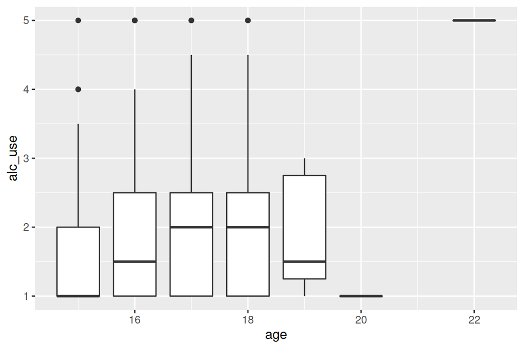

```r
ggplot(alc, aes(y = alc_use, x = age, group = age)) + geom_boxplot()
```

The table above shows there are 7 groups from 15 years old to 22 years old in the dataset. From this table, we can see there is a positive correlation between age and average alcohol consumption, except age group 19 and 20. This is generally aligned with the box chart I made, which shows that the distribution of alcohol consumption goes up when students getting older. This means my hypothesis about age and alcohol consumption generally holds.

```r
alc %>% group_by(freetime) %>% summarise(alcohol_consumption = mean(alc_use))
```

```
## # A tibble: 5 × 2
##   freetime alcohol_consumption
##      <dbl>               <dbl>
## 1        1                1.56
## 2        2                1.72
## 3        3                1.79
## 4        4                2.05
## 5        5                2.28
```

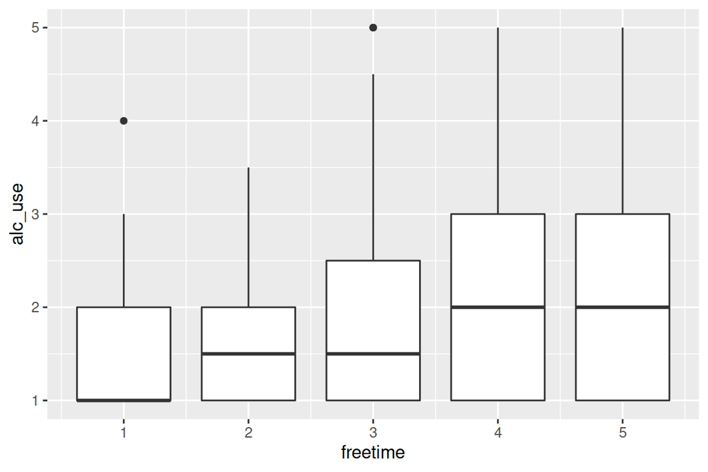

```r
ggplot(alc, aes(y = alc_use, x = freetime, group = freetime)) + geom_boxplot()
```

This table shows a positive correlation between `freetime` and average `alc_use` as well. The box chart shows that the distribution of `alc_use` are more spread out and reach to a higher value, if there is a higher `freetime`.

```r
alc %>% group_by(goout) %>% summarise(alcohol_consumption = mean(alc_use))
```

```
## # A tibble: 5 × 2
##   goout alcohol_consumption
##   <dbl>               <dbl>
## 1     1                1.41
## 2     2                1.56
## 3     3                1.71
## 4     4                2.14
## 5     5                2.73
```

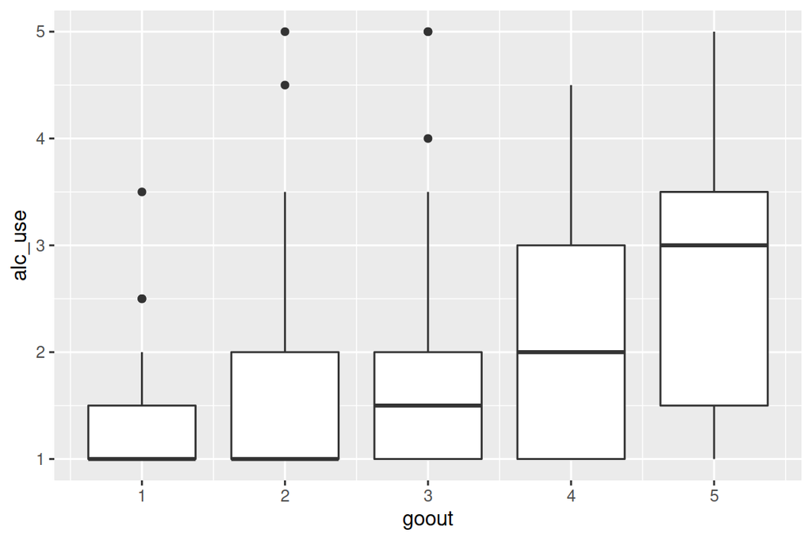

```r
ggplot(alc, aes(y = alc_use, x = goout, group = goout)) + geom_boxplot()
```

Similar as the previous two variables, the result shows there is a positive correlation between `goout` and average `alc_use`. This is also confirmed with the box plot. My hypothesis about students who goes out more with friends may consume more alcohol generally holds true.

```r
alc %>% group_by(famrel) %>% summarise(alcohol_consumption = mean(alc_use))
```

```
## # A tibble: 5 × 2
##   famrel alcohol_consumption
##    <dbl>               <dbl>
## 1      1                2.25
## 2      2                2.19
## 3      3                2
## 4      4                1.88
## 5      5                1.74
```

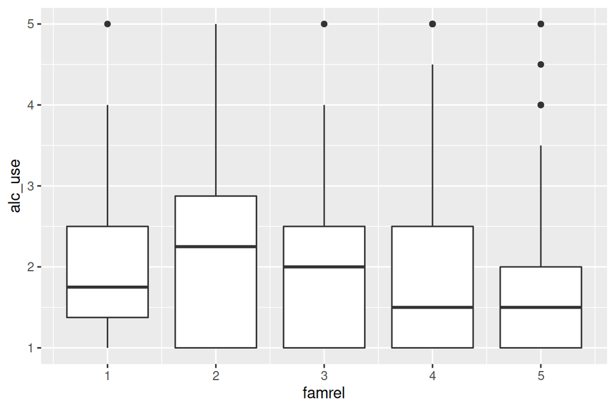

```r
ggplot(alc, aes(y = alc_use, x = famrel, group = famrel)) + geom_boxplot()
```

## Logistic regression

```r
model <- glm(high_use ~ age + freetime + goout + famrel, data = alc, family = "binomial")
summary(model)
```

```
##
## Call:
## glm(formula = high_use ~ age + freetime + goout + famrel, family = "binomial",
##     data = alc)
##
## Deviance Residuals:
##     Min       1Q   Median       3Q      Max
## -1.6976  -0.8063  -0.5542   0.9595   2.4772
##
## Coefficients:
##             Estimate Std. Error z value Pr(>|z|)
## (Intercept)  -4.3760     1.8489  -2.367  0.01794 *
## age           0.1279     0.1069   1.196  0.23160
## freetime      0.2089     0.1369   1.526  0.12695
## goout         0.7208     0.1241   5.807 6.38e-09 ***
## famrel       -0.4256     0.1376  -3.092  0.00199 **
## ---
## Signif. codes:  0 '***' 0.001 '**' 0.01 '*' 0.05 '.' 0.1 ' ' 1
##
## (Dispersion parameter for binomial family taken to be 1)
##
##     Null deviance: 452.04  on 369  degrees of freedom
## Residual deviance: 391.01  on 365  degrees of freedom
## AIC: 401.01
##
## Number of Fisher Scoring iterations: 4
```

As what the model summary shows, `goout` and `famrel` are the two most significant variables when predicting `high_use`. The p-value of these two variables are 6.38e-09 and 0.00199 respectively. The other two variables `age` and `freetime` are less significant.

```r
OR <- coef(model) %>% exp
CI <- confint(model)
cbind(OR, CI)
```

```
##                     OR       2.5 %     97.5 %
## (Intercept) 0.01257509 -8.05653672 -0.7821400
## age         1.13647295 -0.08120815  0.3394566
## freetime    1.23230323 -0.05804507  0.4799409
## goout       2.05616312  0.48382325  0.9716157
## famrel      0.65340188 -0.69939890 -0.1577806
```

According to the odd ratio tables, we can see that `goout` has a strong positive connection with `high_use` (OR > 2), while `famrel` has a strong negative relationship with `high_use` (OR < 1). `age` and `freetime` also have a positive relationship with `high_use`. But they are less significant as `goout`. This suggests my previous hypothesis generally holds true

## Explore the predictive power of my model

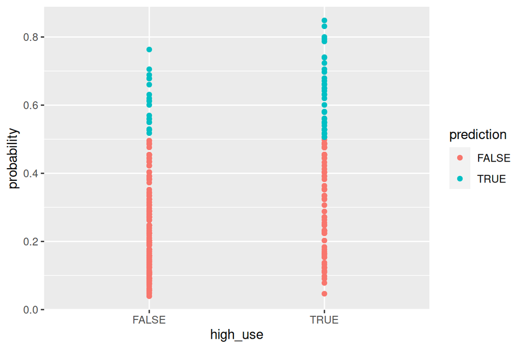

```r
alc <- mutate(alc, probability = predict(model, type = "response"))
alc <- mutate(alc, prediction = probability > 0.5)

g <- ggplot(alc, aes(x = high_use, y = probability, col = prediction))
g + geom_point()
```

```r
table(high_use = alc$high_use, prediction = alc$prediction) %>% prop.table %>% addmargins
```

```
##         prediction
## high_use      FALSE       TRUE        Sum
##    FALSE 0.64594595 0.05405405 0.70000000
##    TRUE  0.19189189 0.10810811 0.30000000
##    Sum   0.83783784 0.16216216 1.00000000
```

```r
loss_func <- function(class, prob) {
  n_wrong <- abs(class - prob) > 0.5
  mean(n_wrong)
}



loss_func(class = alc$high_use, prob = alc$prediction)
```

```
## [1] 0.2459459
```

```r
loss_func(class = alc$high_use, prob = runif(nrow(alc), 0, 1) > 0.5) # Random guessing
```

```
## [1] 0.4972973
```

The training error is 24.6%, which is lower than fliping a coin without any proof and guessing 1 for all observations. This means the variables I selected and the model I trained are effective. However, guessing 0 for all achieves 30% error rate, which is close to my result. This suggest the data itself is not balanced, but it also makes sense because high school students are generally less likely to have a drinking problem.

## Bonus: 10-fold cross-validation

```r
model_2 <- glm(high_use ~ absences + failures + goout + famrel, data = alc, family = "binomial")
cv <- cv.glm(data = alc, cost = loss_func, glmfit = model_2, K = 10)
cv$delta[1]
```

```
## [1] 0.2459459
```

I replaced the two least significant variables in my initial model with the two most significant variables in the model introduced in the Exercise Set. The result is slightly better than the result in Exercise Set

## Super-Bonue: Compare the performance of different logistic regression models

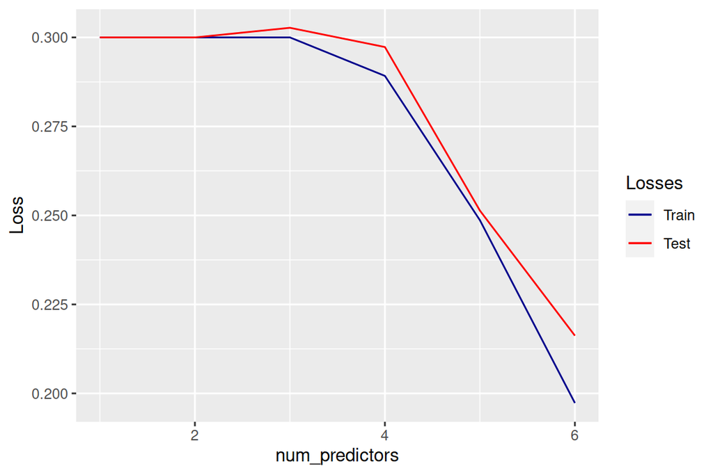

```r
all_predictors <- rev(c('goout', 'absences', 'failures', 'famrel', 'health', 'sex'))
num_predictors <- length(all_predictors):1

train_losses <- c()
test_losses <- c()

for( i in num_predictors){
    predictors <- all_predictors[1:i]
    f <- as.formula(paste('high_use', paste(predictors, collapse = ' + '), sep = ' ~ '))
    glm <- glm(f, data = alc, family = "binomial")
    alc <- mutate(alc, probability = predict(glm, type = "response"))
    alc <- mutate(alc, prediction = probability > 0.5)
    train_loss <- loss_func(class = alc$high_use, prob = alc$prediction)
    train_losses <- append(train_losses, train_loss)

    cv <- cv.glm(data = alc, cost = loss_func, glmfit = glm, K = 10)
    test_loss <- cv$delta[1]
    test_losses <- append(test_losses, test_loss)

}


df = data.frame(num_predictors, train_losses, test_losses)
ggplot(df, aes(num_predictors)) +                    # basic graphical object
  geom_line(aes(y=train_losses, colour="Train")) +  # first layer
  geom_line(aes(y=test_losses, colour="Test")) +  # second layer
  scale_color_manual(name = "Losses", values = c("Train" = "darkblue", "Test" = "red")) +
  ylab("Loss")
```

# Clustering and classification

```r
date()
```

```
## [1] "Sat Nov 12 17:58:22 2022"
```

```r
library(MASS)
library(dplyr)
library(tidyverse)
data("Boston")
```

## Load data

```r
str(Boston)
```

```
## 'data.frame':    506 obs. of  14 variables:
##  $ crim   : num  0.00632 0.02731 0.02729 0.03237 0.06905 ...
##  $ zn     : num  18 0 0 0 0 0 12.5 12.5 12.5 12.5 ...
##  $ indus  : num  2.31 7.07 7.07 2.18 2.18 2.18 7.87 7.87 7.87 7.87 ...
##  $ chas   : int  0 0 0 0 0 0 0 0 0 0 ...
##  $ nox    : num  0.538 0.469 0.469 0.458 0.458 0.458 0.524 0.524 0.524 0.524 ...
##  $ rm     : num  6.58 6.42 7.18 7 7.15 ...
##  $ age    : num  65.2 78.9 61.1 45.8 54.2 58.7 66.6 96.1 100 85.9 ...
##  $ dis    : num  4.09 4.97 4.97 6.06 6.06 ...
##  $ rad    : int  1 2 2 3 3 3 5 5 5 5 ...
##  $ tax    : num  296 242 242 222 222 222 311 311 311 311 ...
##  $ ptratio: num  15.3 17.8 17.8 18.7 18.7 18.7 15.2 15.2 15.2 15.2 ...
##  $ black  : num  397 397 393 395 397 ...
##  $ lstat  : num  4.98 9.14 4.03 2.94 5.33 ...
##  $ medv   : num  24 21.6 34.7 33.4 36.2 28.7 22.9 27.1 16.5 18.9 ...
```

## Graphical overview and variable summary

[figure not shown]

```r
pairs(Boston)
```

```r
summary(Boston)
```

```
##       crim                zn             indus            chas
##  Min.   : 0.00632   Min.   :  0.00   Min.   : 0.46   Min.   :0.00000
##  1st Qu.: 0.08205   1st Qu.:  0.00   1st Qu.: 5.19   1st Qu.:0.00000
##  Median : 0.25651   Median :  0.00   Median : 9.69   Median :0.00000
##  Mean   : 3.61352   Mean   : 11.36   Mean   :11.14   Mean   :0.06917
##  3rd Qu.: 3.67708   3rd Qu.: 12.50   3rd Qu.:18.10   3rd Qu.:0.00000
##  Max.   :88.97620   Max.   :100.00   Max.   :27.74   Max.   :1.00000
##       nox               rm             age              dis
##  Min.   :0.3850   Min.   :3.561   Min.   :  2.90   Min.   : 1.130
##  1st Qu.:0.4490   1st Qu.:5.886   1st Qu.: 45.02   1st Qu.: 2.100
##  Median :0.5380   Median :6.208   Median : 77.50   Median : 3.207
##  Mean   :0.5547   Mean   :6.285   Mean   : 68.57   Mean   : 3.795
##  3rd Qu.:0.6240   3rd Qu.:6.623   3rd Qu.: 94.08   3rd Qu.: 5.188
##  Max.   :0.8710   Max.   :8.780   Max.   :100.00   Max.   :12.127
##       rad              tax           ptratio          black
##  Min.   : 1.000   Min.   :187.0   Min.   :12.60   Min.   :  0.32
##  1st Qu.: 4.000   1st Qu.:279.0   1st Qu.:17.40   1st Qu.:375.38
##  Median : 5.000   Median :330.0   Median :19.05   Median :391.44
##  Mean   : 9.549   Mean   :408.2   Mean   :18.46   Mean   :356.67
##  3rd Qu.:24.000   3rd Qu.:666.0   3rd Qu.:20.20   3rd Qu.:396.23
##  Max.   :24.000   Max.   :711.0   Max.   :22.00   Max.   :396.90
##      lstat            medv
##  Min.   : 1.73   Min.   : 5.00
##  1st Qu.: 6.95   1st Qu.:17.02
##  Median :11.36   Median :21.20
##  Mean   :12.65   Mean   :22.53
##  3rd Qu.:16.95   3rd Qu.:25.00
##  Max.   :37.97   Max.   :50.00
```